# problema1-cp1

Vinicius Brandão

## Conjunto de dados utilizado

Análise exploratória de dados do [IMDB](https://www.imdb.com/) sobre seriados de TV e Streaming. Os dados originais e as variáveis vem de [neste repositorio](https://github.com/nazareno/imdb-series) . Lá tem a explicação de como os dados foram gerados e do significado de cada variável.

```r
dados <- read_csv(here("data/series_from_imdb.csv"),
                    progress = FALSE,
                    col_types = cols(.default = col_double(),
                                     series_name = col_character(),
                                     episode = col_character(),
                                     url = col_character(),
                                     season = col_character()))
```

## Conjunto de dados de analise

Diante do conjunto de dados coletados, onde contem dados sobre algumas séries populares na atualidade. Na análise desse notebook foram escolhidas 3 série bastante popular atualmente, são elas:

- The Blacklist
- House of Cards
- Vikings

```r
    dados_escolhidos <- dados %>%
    filter(series_name %in% c("The Blacklist",
                              "House of Cards",
                              "Vikings"))
```

## Primeira pergunta

Analisaremos o quão bem avaliada as séres no [IMDB](https://www.imdb.com/) e desse modo tentar a chegar a uma aproximação de qual serie diante do conjunto escolhido seria a mais bem avaliada de acordo com os votos dos usuarios.

```r
    dados_escolhidos %>%
    ggplot(aes(user_rating)) +
    geom_histogram(binwidth = .1, fill = 'chocolate1') +
    scale_x_continuous(breaks = seq(7,10,0.5)) +
    labs(y = "Número de ocorrências", x = "Ratings dos usuários")
```

[output not shown]

```r
    dados_escolhidos %>%
    ggplot(aes(x= series_name,
               y = user_rating,
               color=series_name)) +
    geom_boxplot(width = .5,
                 outlier.color = NA) +
    geom_jitter(width = 0.2) +
    labs(y = "Ratings dos usuários", x = "Séries Escolhidas")
```

[output not shown]

Notamos que The Blacklist possui um número um pouco superior de episódios, e verificamos também que existe dados discrepantes com nota igual a 7.

```r
sum <- dados_escolhidos %>%
    group_by(series_name) %>%
    summarise(n_episodios = n(),
              media = mean(user_rating),
              mediana =  median(user_rating))

ggplot(data = sum,aes(x = series_name)) +
    geom_point(aes(x = series_name, y = media, color = "Média")) +
    geom_point(aes(x = series_name, y = mediana, color = "Mediana"))
```

[output not shown]

## Mudanças de acordo com as temporadas.

Analisaremos de acordo com as temporadas das séries se ocorreu mudanças siginificativas na avaliação de seus episódios.

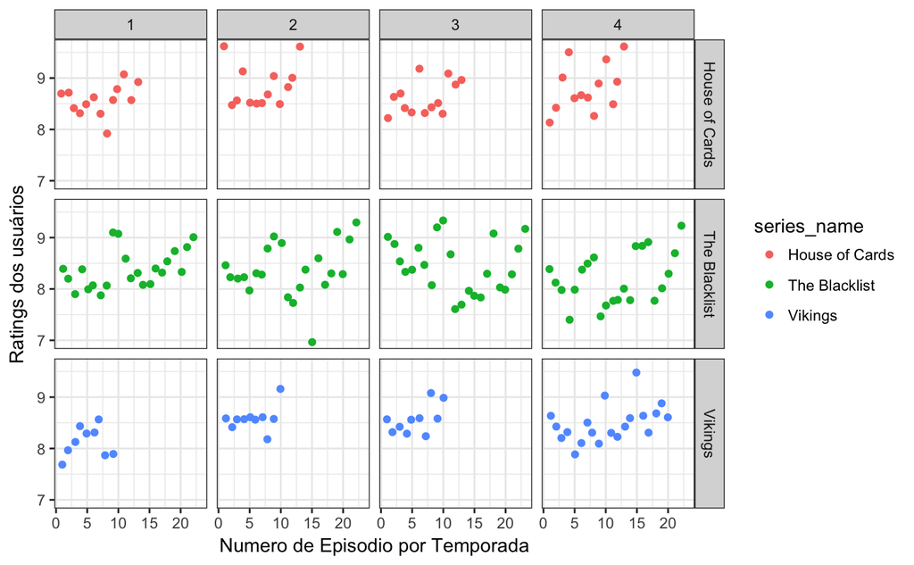

```r
    dados_escolhidos %>%
    ggplot(aes(x = season_ep,
               y = user_rating,
               color = series_name))+
    geom_jitter(width = 0.2) +
    facet_grid(series_name ~ season) +
    labs(y = "Ratings dos usuários", x = "Numero de Episodio por Temporada")
```

```r
NA
```

De acordo com gráfico acima observamos que a série The Blaclist possui uma variação de pontos atribuídos como podemos observar que na primeira temporada a pontuação atribuída se concentram em algo entre 8,0 e 9,0, porém , nas temporadas subsequente observamos que os que pontos vão diminuindo e na quarta temporada eles se dividem na metade ficando uma parte entre 7,0 e 8,0 desse modo verificamos que ao longo das temporadas ocorreu uma mudança considerável. Em relação à série Vikings enxergamos que existe uma diferença da primeira em relação á segunda temporada onde a concentração de pontos está entre 8,0 e 9,0 e mantendo nas temporadas subsequentes. A série House of Cards ao longo de suas temporadas mantêm sua concentração de pontos entre 8,0 e 9,0 e ao longo das temporadas subsequentes verificamos que o número de episódios avaliados acima de 9,0 aumenta. Diante disso, verificamos que às três séries se mantêm no intervalo de 8,0 e 9,0 na avaliação atribuída a seus episódios á partir disto verificamos que os episódios são bem avaliados em sua maioria.

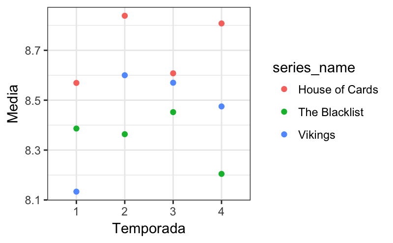

```r
dados_escolhidos %>%
    group_by(series_name,season) %>%
    summarise(media = mean(user_rating)) %>%
    ggplot(aes(x = season, y = media, color = series_name)) +
    geom_point()+
    labs(y = "Media", x = "Temporada")
```

```r
NA
```

Como podemos observar no gráfico acima, verificamos que na 1 temporada a série Vikigs possuía uma média menor entre às duas outras séries, mas como mostrado á partir da segunda temporada conferimos que Vikings aumentou consideravelmente sua média (cerca de 0,5) no, mas o gráfico nos mostra que House of Cards em todas suas temporadas se manteve com uma média de votos dos usuários superior as outras séries.

## Conclusão

Diante das análises observadas acima, consideramos que a série House of Cards como mais bem avaliada pelos usuários no site [IMDB](https://www.imdb.com/) diante no conjunto avaliado, tendo uma diferença pequena entre as outras duas series avaliadas no processo em relação a suas médias e considerando a concentração de votos de House of Cards em sua maioria superior à nota 8,5 e também considerando á analise por temporada verificamos que House of Cards manteve superior sua média de votos por episódio em todas as temporadas sem ter nenhuma variação.

## Qual das séries que você escolheu tem episódios de qualidade mais irregular segundo o IMDB? A diferença é grande? Pequena?

Para responder a essa pergunta, iremos trabalhar com um conceito chamado desvio padrão, um parâmetro muito usado em estatística que indica o grau de variação de um conjunto de elementos. No nosso caso, usaremos o desvio padrão para indicar o grau de varição das avaliações dos episódios de uma série. Portanto, quanto maior o desvio padrão, maior será a irregularidade entre as notas dos episódios de uma série — ou seja, as notas variam muito de um episódio para outro.

```r
dados_escolhidos %>%
    group_by(series_name) %>%
    summarise(dp = sd(user_rating)) %>%
    ggplot(aes(x = reorder(series_name, dp),
           y = dp,
           fill = series_name)) +
    geom_bar(stat = "identity",
           alpha = .7,
           width = .75) +
    labs(y = "Desvio Padrão", x = "Séries Escolhidas")
```

[output not shown]

O IQR é calculado levando em consideração a diferença entre o terceiro e primeiro quartil, ou seja, os 50% de valores mais concentrados.

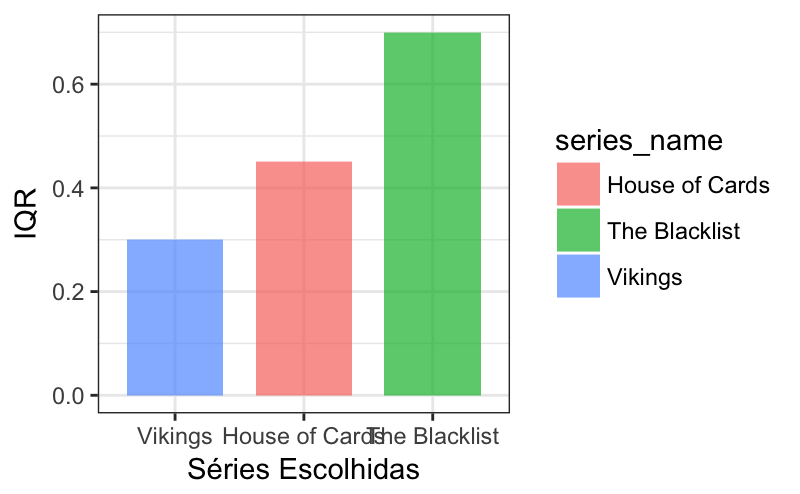

```r
dados_escolhidos %>%
    group_by(series_name) %>%
    summarise(dp = IQR(user_rating)) %>%
    ggplot(aes(x = reorder(series_name, dp),
           y = dp,
           fill = series_name)) +
    geom_bar(stat = "identity",
           alpha = .7,
           width = .75) +
    labs(y = "IQR", x = "Séries Escolhidas")
```

## Episódios no início/fim da temporada são mais bem avaliados que os no meio? O que tende a ser melhor? Inícios ou finais de séries/temporadas?

Analise em questão é sobre os episódios no início/ fim da temporada e verificas se existe alguma diferença entre eles e algo que consideramos que tende a ser melhor .

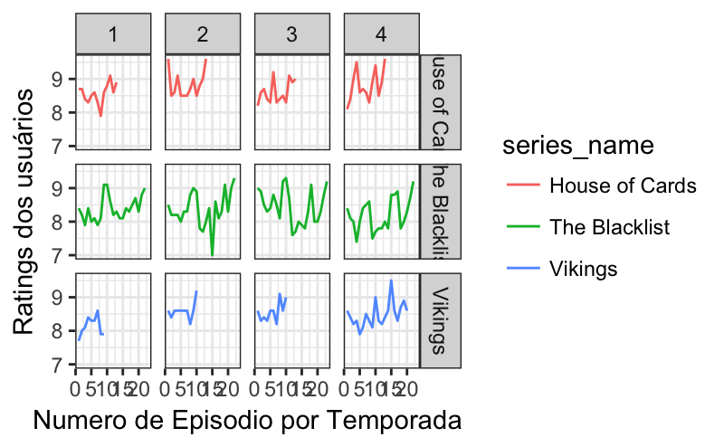

```r
    dados_escolhidos %>%
    ggplot(aes(x = season_ep,
               y = user_rating,
               color = series_name,
               group = series_name))+
    geom_line() +
    facet_grid(series_name ~ season) +
    labs(y = "Ratings dos usuários", x = "Numero de Episodio por Temporada")
```

```r
NA
```

## Qual das séries ou temporadas tem episódios mais sem graça? (Um episódio é sem graça se ninguém nem ama nem odeia ele)

Analise de episódios mais sem graça e para isso utilizaremos o episódios em que obtiveram mais nota 5 considerando uma nota de 1 á 10 a nota 5 refere a metade do intervalo e desse modo se encaixa no tipo de episódio sem graça.

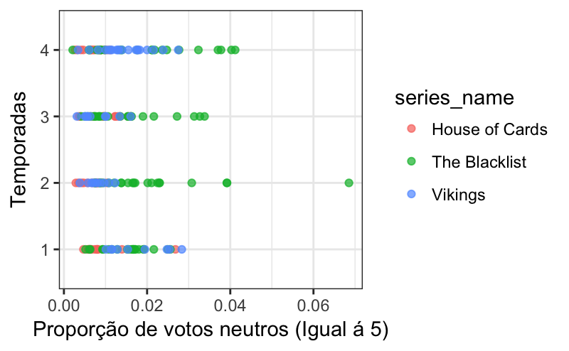

```r
dados_escolhidos %>%
    group_by(series_name) %>%
    ggplot(aes(x = r5, y = season, color = series_name)) +
    geom_point(alpha = .7) +
    labs(y = "Temporadas", x = "Proporção de votos neutros (Igual á 5)")
```

```r
NA
```

Como demostrado no gráfico acima a série que possui maior numero de episódios sem graça é The Blacklist, mas especificamente nas segunda e quarta temporada onde tem um número crescente de episódios sem graça, já na primeira temporada verificamos que Vikings e House of Cards obteve um número maior de número de episódios sem graça, porém isto não influencia no resultado final.